# bioinf_lab2_part2

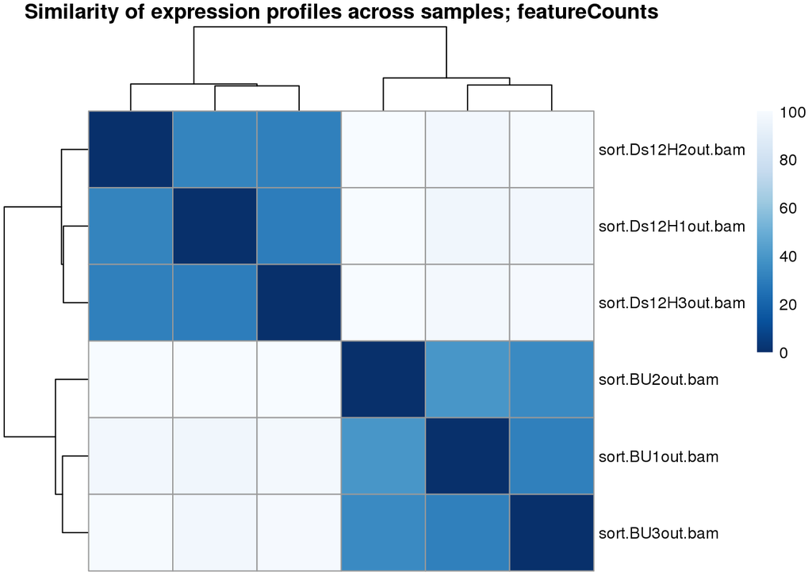

```r
sampleDistMatrix <- as.matrix( sampleDists )
colnames(sampleDistMatrix) <- NULL
colors <- colorRampPalette( rev(brewer.pal(9, "Blues")) )(255)
pheatmap(sampleDistMatrix, clustering_distance_rows=sampleDists, clustering_distance_cols=sampleDists, col=colors, main = "Similarity of expression profiles across samples; featureCounts")
```

Perform Principle Compenent Analysis:

```r
ntd1 <- normTransform(dataset)
##    log2(n+1) transformation, the data that are transformed are read counts normalized for transcript average length and library size

rld1 <- rlog(dataset, blind=FALSE)
#the data that are transformed are read counts normalized for transcript average length and library size

vsd1 <- varianceStabilizingTransformation(dataset, blind=FALSE)
#the data that are transformed are read counts normalized for transcript average length and library size
```

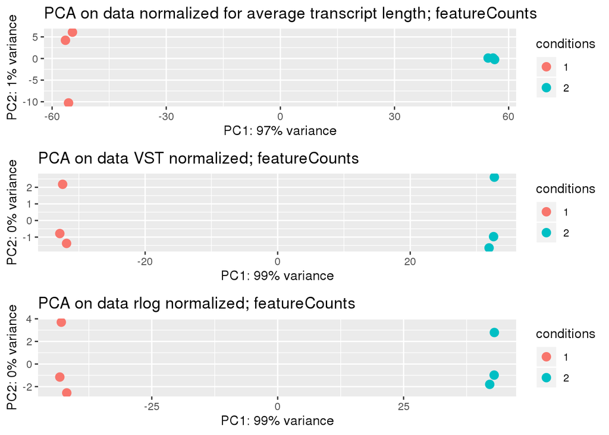

```r
# plot PCA for ntd1
pcaData <- plotPCA(ntd1, intgroup = names(colData(dataset)), returnData=TRUE)
percentVar <- round(100*attr(pcaData, "percentVar"))
p1 <- ggplot(pcaData, aes(PC1, PC2, color=conditions)) + geom_point(size =3) +
  xlab(paste0("PC1: ", percentVar[1], "% variance")) + ylab(paste0("PC2: ", percentVar[2], "% variance")) +
  ggtitle("PCA on data normalized for average transcript length; featureCounts")

# plot PCA for vsd1
pcaData <- plotPCA(vsd1, intgroup = names(colData(dataset)), returnData=TRUE)
percentVar <- round(100*attr(pcaData, "percentVar"))
p2 <- ggplot(pcaData, aes(PC1, PC2, color=conditions)) + geom_point(size =3) +
  xlab(paste0("PC1: ", percentVar[1], "% variance")) + ylab(paste0("PC2: ", percentVar[2], "% variance")) +
  ggtitle("PCA on data VST normalized; featureCounts")

# plot PCA for rld1
pcaDatar <- plotPCA(rld1, intgroup = names(colData(dataset)), returnData=TRUE)
percentVarr <- round(100*attr(pcaDatar, "percentVar"))
p3 <- ggplot(pcaDatar, aes(PC1, PC2, color=conditions)) + geom_point(size =3) +
  xlab(paste0("PC1: ", percentVarr[1], "% variance")) + ylab(paste0("PC2: ", percentVarr[2], "% variance")) +
  ggtitle("PCA on data rlog normalized; featureCounts")


grid.arrange(p1,p2,p3, nrow=3)
```

Generate MA plot:

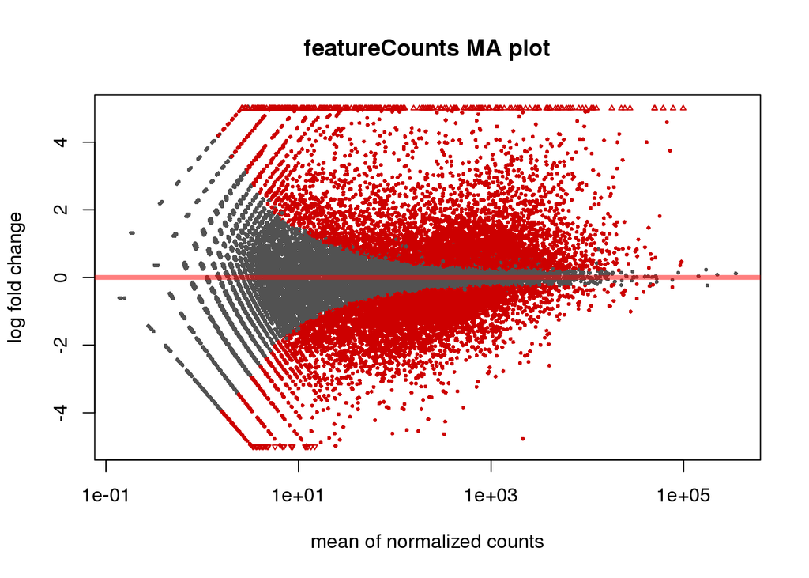

```r
plotMA(res, ylim = c(-5, 5), main = "featureCounts MA plot")
```

```r
#shrink fold changes in data:
res <- lfcShrink(processed_dataset, contrast=c("conditions","1","2"))
```

```
## using 'normal' for LFC shrinkage, the Normal prior from Love et al (2014).
##
## Note that type='apeglm' and type='ashr' have shown to have less bias than type='normal'.
## See ?lfcShrink for more details on shrinkage type, and the DESeq2 vignette.
## Reference: https://doi.org/10.1093/bioinformatics/bty895
```

```r
#average treatment conditions
baseMeanCtrl = rowMeans(counts(processed_dataset,normalized=TRUE)[,processed_dataset$condition == "Control"])
baseMeanTreat = rowMeans(counts(processed_dataset,normalized=TRUE)[,processed_dataset$condition == "Treatment"])
res = cbind(as.data.frame(res), baseMeanCtrl, baseMeanTreat)

#make temporary column of gene_ids, and drop characters after the "."
tmp=gsub("\\..*","",row.names(res))

# map gene_ids
res$symbol <- mapIds(org.Hs.eg.db, keys=tmp, column="SYMBOL", keytype="ENSEMBL", multiVals="first")
res$entrez <- mapIds(org.Hs.eg.db, keys=tmp, column="ENTREZID", keytype="ENSEMBL", multiVals="first")
```

Generate histograms of p-values for each gene (second plot filters out genes with low counts)

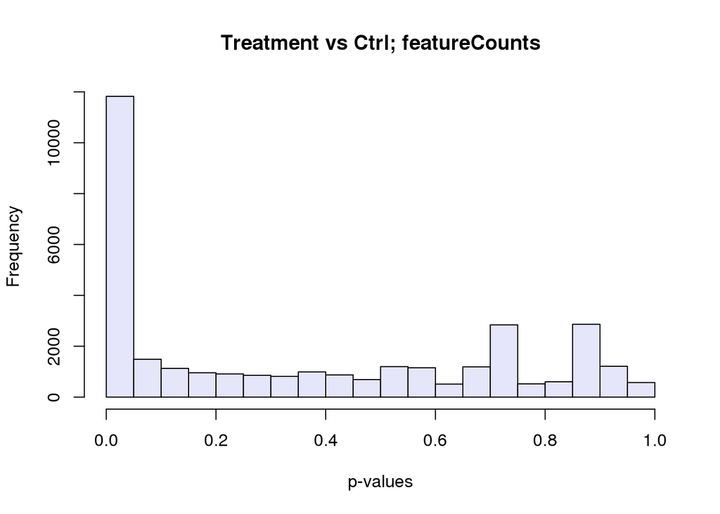

```r
hist(res$pvalue, col = "lavender", main = "Treatment vs Ctrl; featureCounts", xlab = "p-values")
```

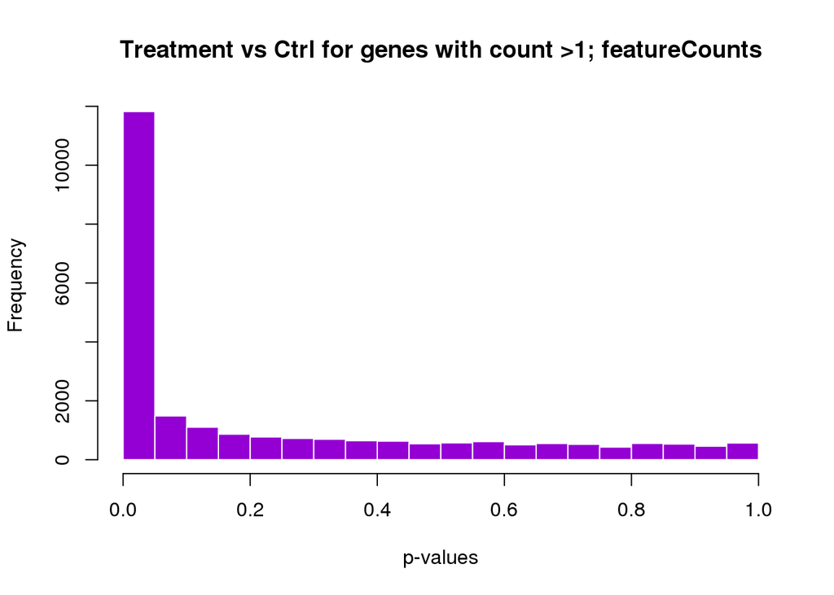

```r
hist(res$pvalue[res$baseMean > 1], breaks = 0:20/20, col = "darkviolet", border = "white",
     main = "Treatment vs Ctrl for genes with count >1; featureCounts",
     xlab = "p-values") #this one states that genes with average count <1 should not be included in the graph
```

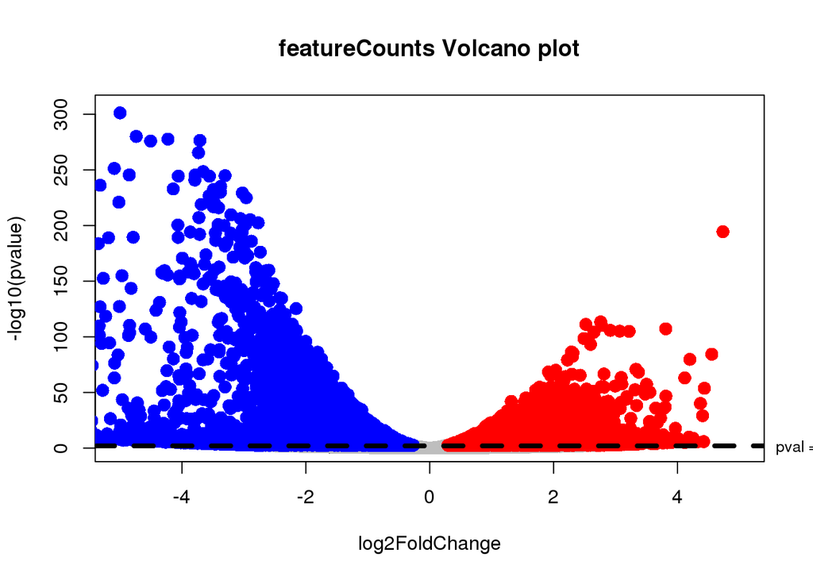

```r
### VOLCANO PLOTS
with(res, plot(log2FoldChange, -log10(pvalue), pch=16, cex=1.5, main="featureCounts Volcano plot", xlim=c(-5,5)))
with(subset(res, padj>0.01), points(log2FoldChange, -log10(pvalue), pch=16, cex=1.5, col="gray"))
with(subset(res, padj<0.01 & log2FoldChange>0), points(log2FoldChange, -log10(pvalue), pch=16, cex=1.5, col="red"))
with(subset(res, padj<0.01 & log2FoldChange<0), points(log2FoldChange, -log10(pvalue), pch=16, cex=1.5, col="blue"))
### ADD BELLS AND WHISTLES
pval = 0.01
abline(h = -log10(pval), col = "black", lty = 2, lwd=4)
mtext(paste("pval = 0.01", pval), side = 4, at = -log10(pval), cex = 0.8, line = 0.5, las = 1)
```

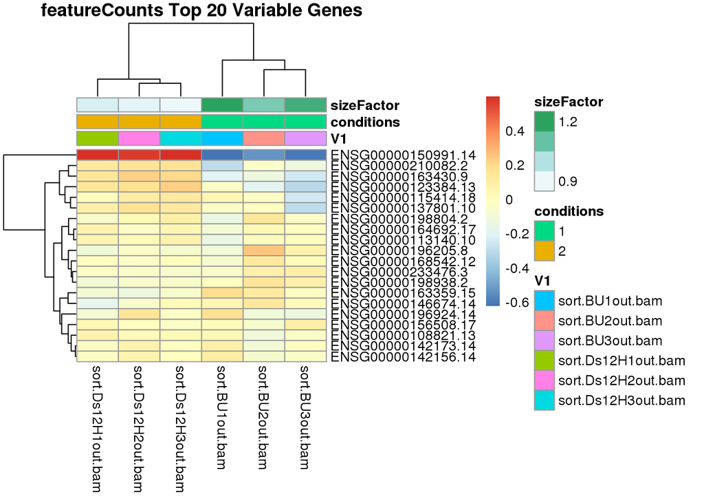

```r
### Plot heatmap - top20 variable genes
rld <- rlog(processed_dataset)
df <- as.data.frame(colData(processed_dataset))
topVarGenes <- head( order( rowMeans( assay(rld) ), decreasing=TRUE ), 20 )
mat <- assay(rld)[topVarGenes, ]
mat<-mat-rowMeans(mat) ##plot distances from the mean, makes heatmap clearer
mart <- useMart("ensembl","hsapiens_gene_ensembl") ## assuming human
gns <- getBM(c("hgnc_symbol","ensembl_gene_id"), "ensembl_gene_id", row.names(mat), mart)
row.names(mat)[match(gns[,2], row.names(mat))] <- gns[,1]
pheatmap(mat, cluster_rows=TRUE, show_rownames=TRUE, cluster_cols=TRUE, annotation_col=df, main = "featureCounts Top 20 Variable Genes")
```

```r
mart
```

```
## Object of class 'Mart':
##   Using the ENSEMBL_MART_ENSEMBL BioMart database
##   Using the hsapiens_gene_ensembl dataset
```

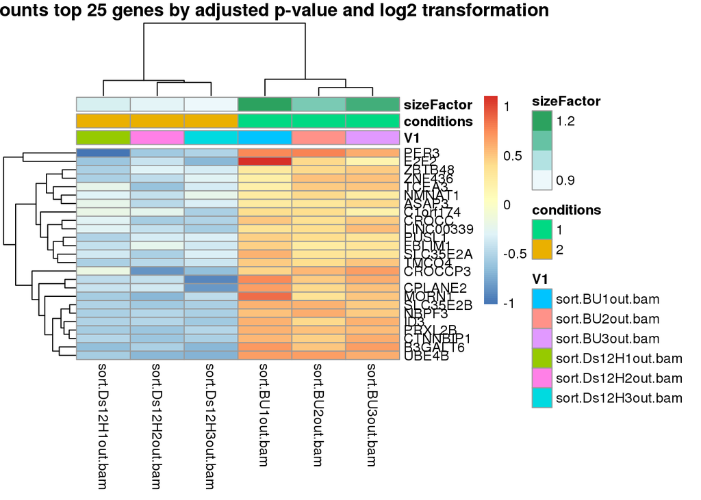

```r
### Plot heatmap - sorting by padj and log2fc
# PICK ALL GENES WITH pADJ < 0.05 AND THEN SUBSET FOR THOSE WITH Log2FC > 1 THEN PICK TOP 25 HITS
subset <- head((subset(res, res$log2FoldChange > 1 & res$padj < 0.00001)), n=25)
sigGenes <- rownames(subset)
rows <- match(sigGenes, row.names(rld))
mat <- assay(rld)[rows,]
mat<-mat-rowMeans(mat) ##plot distances from the mean, makes heatmap clearer
mart <- useMart("ensembl","hsapiens_gene_ensembl") ## assuming human
gns <- getBM(attributes = c("hgnc_symbol","ensembl_gene_id", "external_gene_name"),
             filter = "ensembl_gene_id", value=gsub("\\..*","",row.names(mat)), mart)
row.names(mat) <- gsub("\\..*","",row.names(mat))
row.names(mat)[match(gns[,2], row.names(mat))] <- gns[,1]
df <- as.data.frame(colData(processed_dataset))
row.names(mat) <- gsub("\\..*","",row.names(mat))
pheatmap(mat, cluster_rows=TRUE, show_rownames=TRUE, cluster_cols=TRUE, annotation_col=df,
         main = "featureCounts top 25 genes by adjusted p-value and log2 transformation")
```

**Step 2: Kallisto**

```r
library("tximport")
library("gridExtra")


### IMPORT ENSEMBl ANNOTATIONS FOR HUMAN GENOME & GENERATE TWO COLUMN FILE LINKING TRANSCRIPT AND GENE IDS
mart <- biomaRt::useMart(biomart = "ensembl", dataset =  "hsapiens_gene_ensembl")
t2g <- biomaRt::getBM(attributes = c("ensembl_transcript_id", "transcript_version", "ensembl_gene_id", "external_gene_name", "description", "transcript_biotype", "refseq_mrna", "refseq_ncrna"), mart = mart)
t2g$target_id <- paste(t2g$ensembl_transcript_id, t2g$transcript_version, sep=".") # append version number to the transcript ID
t2g[,c("ensembl_transcript_id","transcript_version")] <- list(NULL) # delete the ensembl transcript ID and transcript version columns
t2g <- dplyr::rename( t2g, gene_symbol = external_gene_name, full_name = description, biotype = transcript_biotype )
t2g<-t2g[,c(ncol(t2g),1:(ncol(t2g)-1))]
```

```r
### GENERATE ADDITIONAL OBJECT CONTAINING ONLY PROTEIN CODING GENES [OPTIONAL]
gb <- getBM(attributes=c("ensembl_gene_id","gene_biotype"), mart=mart)
gb_coding<-subset(gb, gb$gene_biotype=="protein_coding")
genes<-gb_coding$ensembl_gene_id
```

Set up metadata for DESeq2:

```r
conditions = c("Control", "Control", "Control", "Treatment", "Treatment", "Treatment")
conditions = as.factor(conditions)
sample_treatments = cbind(count_output[[3]], conditions)
```

Run differnetial gene expression analysis using DESeq2:

```r
# setup:
dataset <- DESeqDataSetFromMatrix(
  countData = counts,
  colData = sample_treatments,
  design = ~conditions
  )
# run DESeq and evaluate results:
processed_dataset <- DESeq(dataset)
res <- results(processed_dataset)
```

An exploratory look at the data:

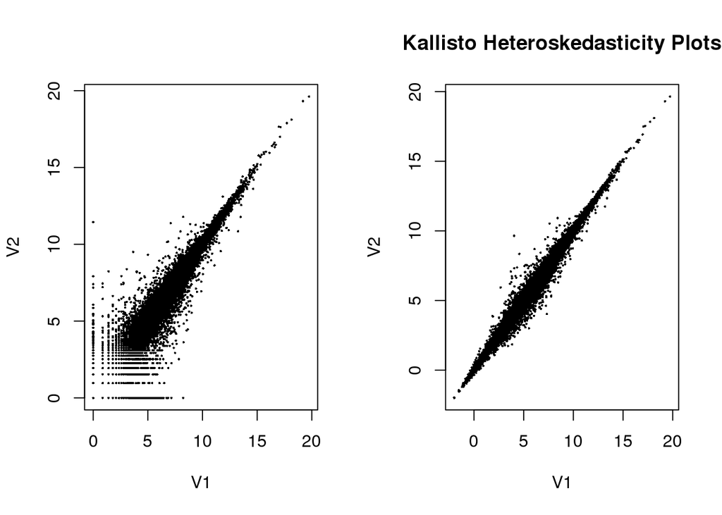

```r
## EXPLORATORY PLOTTING:
rlog <- rlog(dataset)
par( mfrow = c( 1, 2 ) )
dataset <- estimateSizeFactors(dataset)

# heteroskedasticity plots:
plot(log2( 1 + counts(dataset, normalized=TRUE)[ , 1:2] ), pch=16, cex=0.3)
plot(assay(rlog)[ , 1:2], pch=16, cex=0.3, main = "Kallisto Heteroskedasticity Plots")
```

```r
### Take a look at sample distributions
sampleDists <- dist( t( assay(rlog) ) )
sampleDists
```

```
##          V1       V2       V3       V4       V5
## V2 48.23381
## V3 43.69613 41.34681
## V4 84.28719 89.85697 88.58732
## V5 84.82826 90.29875 89.29475 38.91429
## V6 85.87227 89.94317 89.58605 39.01281 39.74594
```

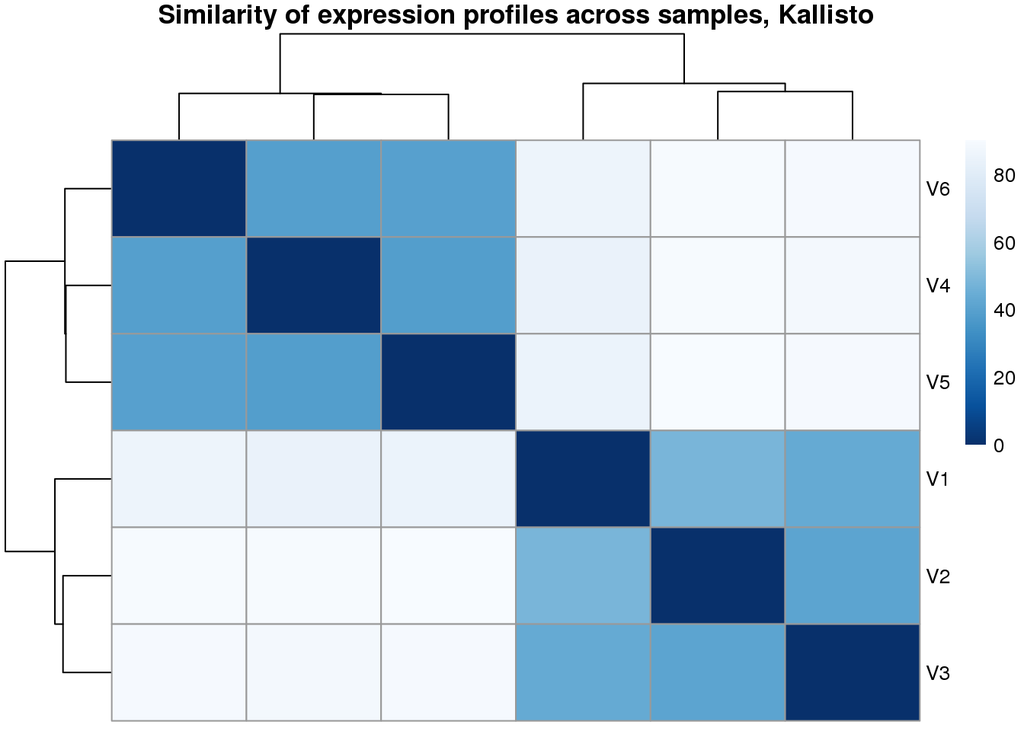

```r
sampleDistMatrix <- as.matrix( sampleDists )
colnames(sampleDistMatrix) <- NULL
colors <- colorRampPalette( rev(brewer.pal(9, "Blues")) )(255)
pheatmap(sampleDistMatrix, clustering_distance_rows=sampleDists, clustering_distance_cols=sampleDists, col=colors, main = "Similarity of expression profiles across samples, Kallisto")
```

Perform Principle Compenent Analysis:

```r
ntd1 <- normTransform(dataset)
##    log2(n+1) transformation, the data that are transformed are read counts normalized for transcript average length and library size

rld1 <- rlog(dataset, blind=FALSE)
#the data that are transformed are read counts normalized for transcript average length and library size

vsd1 <- varianceStabilizingTransformation(dataset, blind=FALSE)
#the data that are transformed are read counts normalized for transcript average length and library size
```

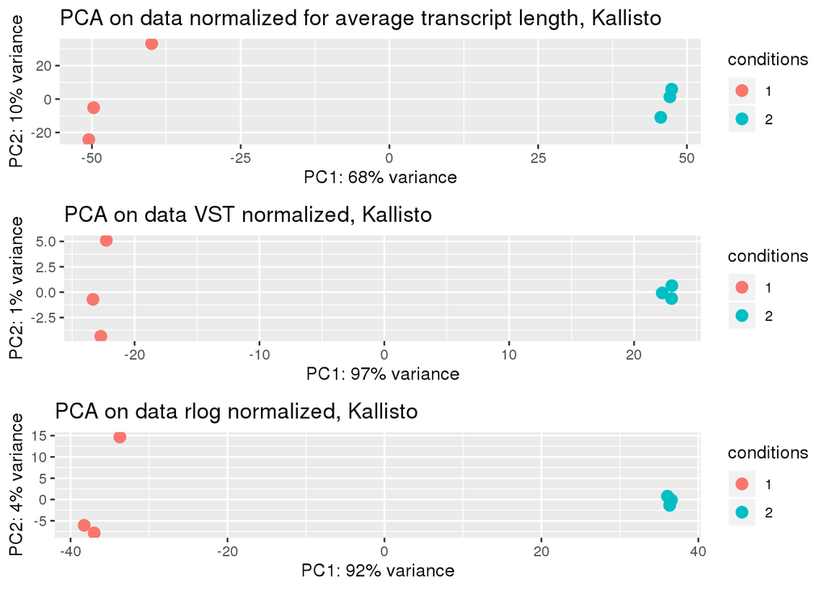

```r
library("gridExtra")

# plot PCA for ntd1
pcaData <- plotPCA(ntd1, intgroup = names(colData(dataset)), returnData=TRUE)
percentVar <- round(100*attr(pcaData, "percentVar"))
p1 <- ggplot(pcaData, aes(PC1, PC2, color=conditions)) + geom_point(size =3) +
  xlab(paste0("PC1: ", percentVar[1], "% variance")) + ylab(paste0("PC2: ", percentVar[2], "% variance")) +
  ggtitle("PCA on data normalized for average transcript length, Kallisto")

# plot PCA for vsd1
pcaData <- plotPCA(vsd1, intgroup = names(colData(dataset)), returnData=TRUE)
percentVar <- round(100*attr(pcaData, "percentVar"))
p2 <- ggplot(pcaData, aes(PC1, PC2, color=conditions)) + geom_point(size =3) +
  xlab(paste0("PC1: ", percentVar[1], "% variance")) + ylab(paste0("PC2: ", percentVar[2], "% variance")) +
  ggtitle("PCA on data VST normalized, Kallisto")

# plot PCA for rld1
pcaDatar <- plotPCA(rld1, intgroup = names(colData(dataset)), returnData=TRUE)
percentVarr <- round(100*attr(pcaDatar, "percentVar"))
p3 <- ggplot(pcaDatar, aes(PC1, PC2, color=conditions)) + geom_point(size =3) +
  xlab(paste0("PC1: ", percentVarr[1], "% variance")) + ylab(paste0("PC2: ", percentVarr[2], "% variance")) +
  ggtitle("PCA on data rlog normalized, Kallisto")


grid.arrange(p1,p2,p3, nrow=3)
```

Generate MA plot:

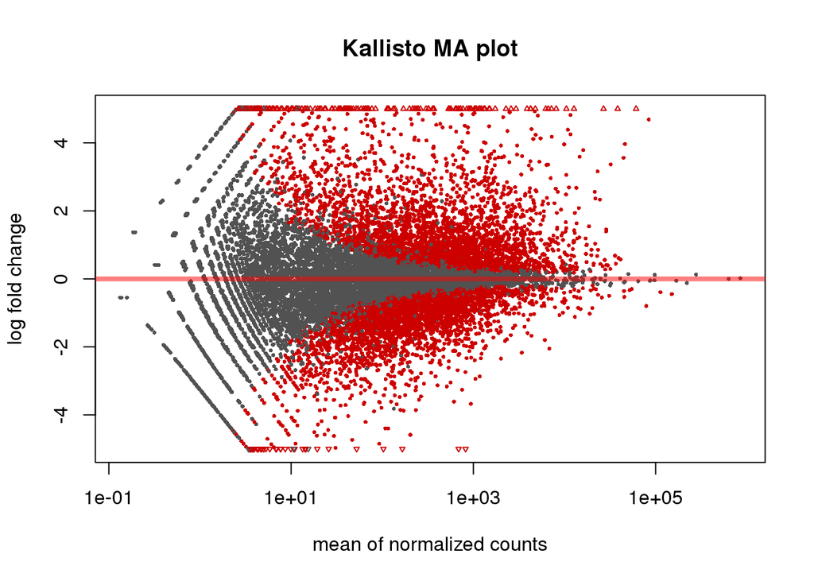

```r
plotMA(res, ylim = c(-5, 5), main = "Kallisto MA plot")
```

```r
#shrink fold changes in data:
res <- lfcShrink(processed_dataset, contrast=c("conditions","1","2"))
```

```
## using 'normal' for LFC shrinkage, the Normal prior from Love et al (2014).
##
## Note that type='apeglm' and type='ashr' have shown to have less bias than type='normal'.
## See ?lfcShrink for more details on shrinkage type, and the DESeq2 vignette.
## Reference: https://doi.org/10.1093/bioinformatics/bty895
```

```r
#average treatment conditions
baseMeanCtrl = rowMeans(counts(processed_dataset,normalized=TRUE)[,processed_dataset$condition == "Control"])
baseMeanTreat = rowMeans(counts(processed_dataset,normalized=TRUE)[,processed_dataset$condition == "Treatment"])
res = cbind(as.data.frame(res), baseMeanCtrl, baseMeanTreat)

#make temporary column of gene_ids, and drop characters after the "."
tmp=gsub("\\..*","",row.names(res))

# map gene_ids
res$symbol <- mapIds(org.Hs.eg.db, keys=tmp, column="SYMBOL", keytype="ENSEMBL", multiVals="first")
res$entrez <- mapIds(org.Hs.eg.db, keys=tmp, column="ENTREZID", keytype="ENSEMBL", multiVals="first")
```

Generate histograms of p-values for each gene (second plot filters out genes with low counts)

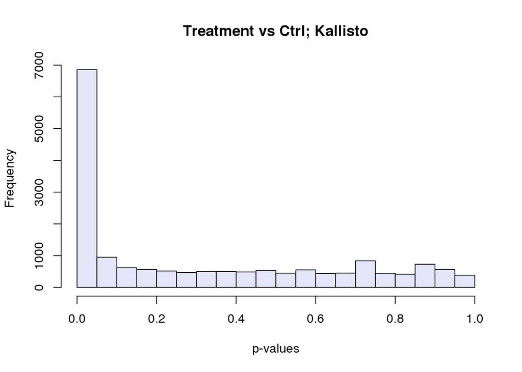

```r
hist(res$pvalue, col = "lavender", main = "Treatment vs Ctrl; Kallisto", xlab = "p-values")
```

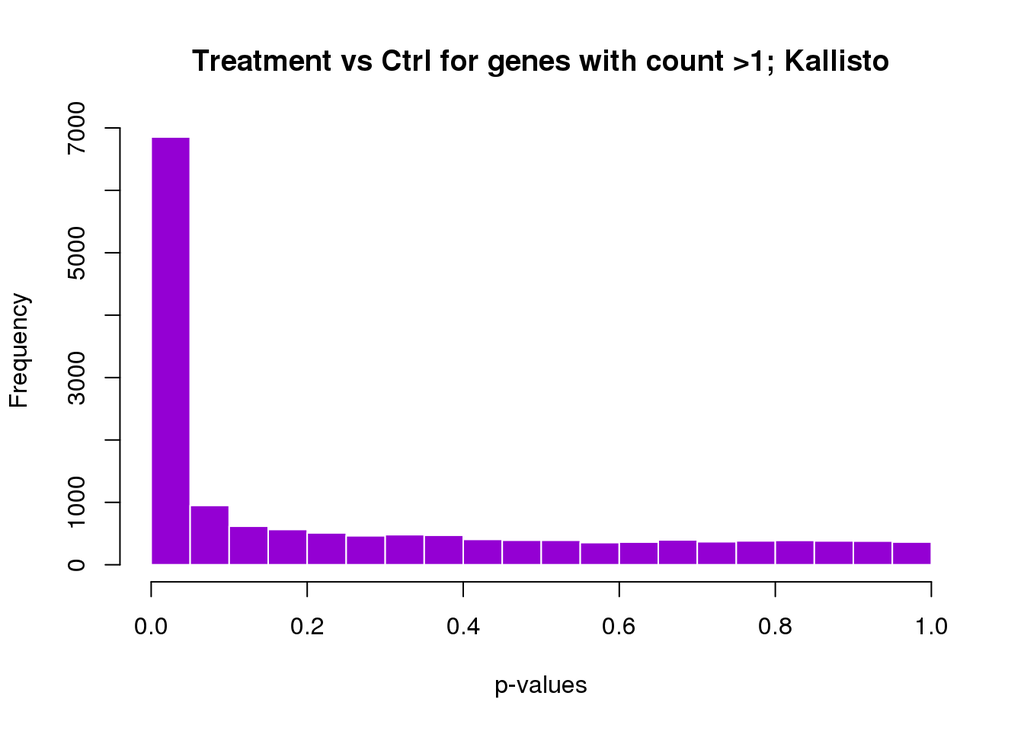

```r
hist(res$pvalue[res$baseMean > 1], breaks = 0:20/20, col = "darkviolet", border = "white",
     main = "Treatment vs Ctrl for genes with count >1; Kallisto",
     xlab = "p-values") #this one states that genes with average count <1 should not be included in the graph
```

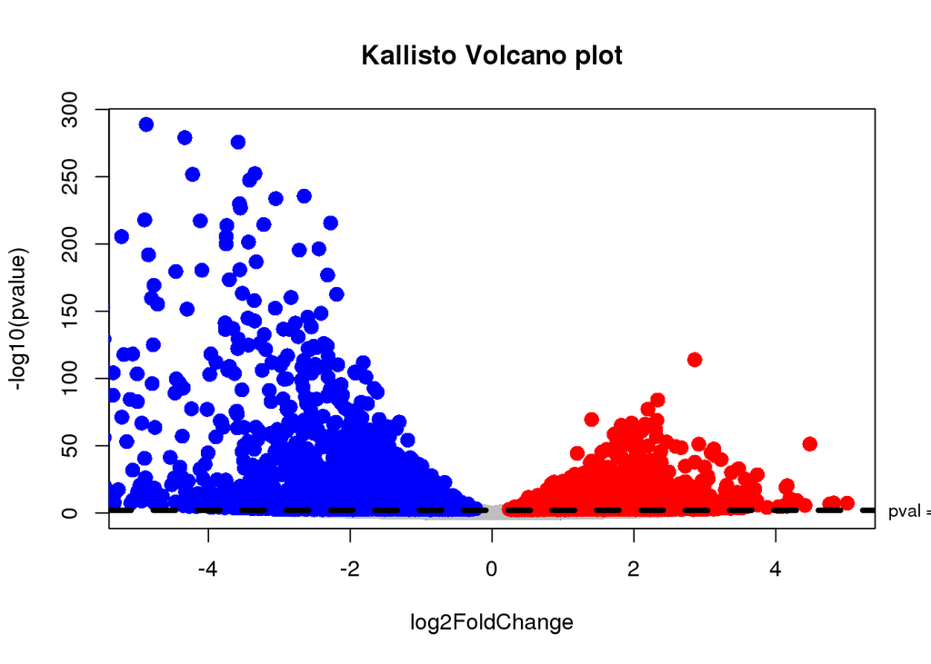

```r
### VOLCANO PLOTS
with(res, plot(log2FoldChange, -log10(pvalue), pch=16, cex=1.5, main="Kallisto Volcano plot", xlim=c(-5,5)))
with(subset(res, padj>0.01), points(log2FoldChange, -log10(pvalue), pch=16, cex=1.5, col="gray"))
with(subset(res, padj<0.01 & log2FoldChange>0), points(log2FoldChange, -log10(pvalue), pch=16, cex=1.5, col="red"))
with(subset(res, padj<0.01 & log2FoldChange<0), points(log2FoldChange, -log10(pvalue), pch=16, cex=1.5, col="blue"))
### ADD BELLS AND WHISTLES
pval = 0.01
abline(h = -log10(pval), col = "black", lty = 2, lwd=4)
mtext(paste("pval = 0.01", pval), side = 4, at = -log10(pval), cex = 0.8, line = 0.5, las = 1)
```